# P1: Test a Perceptual Phenomenon

**Question 1**: What is our independent variable? What is our dependent variable?

**Answer**:

1. Independent variable is "word/color congruency".
2. Dependent variable is "time it takes to name the ink colors in equally-sized lists".

**Question 2**: What is an appropriate set of hypotheses for this task? What kind of statistical test do you expect to perform? Justify your choices.

**Answer**:

Uc -- the mean of time for congruent words condition for population

Ui -- the mean of time for incongruent words condition for population

Ud = Ui - Uc -- the difference of Ui and Uc means

H0 -- null hypothesis

Ha -- alternative hypothesis

H0: Ud = 0 (there is no difference between those sets of times for the population)

Ha: Ud > 0 (it takes more time to say color of ink for incongruent words condition then for congruent words condition for whole population)

1. We don't know mean and standard deviation of whole population
2. We have less than 30 samples
3. We assume that the distributions are Gaussian (normal)

So, from this information we decide that a type of our test will be an one-tailed dependent t-test for paired sample.

**Question 3**: Report some descriptive statistics regarding this dataset. Include at least one measure of central tendency and at least one measure of variability.

**Answer**:

Xc -- mean of congruent set

Xi -- mean of incongruent set

SDc -- standard deviation of congruent set

SDi -- standard deviation of incongruent set

d = Xi - Xc -- the difference of Xi and Xc means (the mean difference)

Sd = sqrt [ (Σ(di - d)^2 / (n - 1) ] -- standard deviation of the differences computed from n matched pairs,

where di -- is the difference for pair i

Congruent:

- Xc = 14.051
- SDc = 3.559

Incongruent:

- Xi = 22.016
- SDi = 4.797

Difference:

- d = 7.965
- Sd = 4.865

**Question 4**: Provide one or two visualizations that show the distribution of the sample data. Write one or two sentences noting what you observe about the plot or plots.

**Answer**:

On the first histogram we see the distribution for congruent set. A mean of this set (14.05) is in the peak of the distribution. So it seems that it can be normal.

On the second histogram we see the distribution of incongruent set. It looks like positive skewed. Also a mean of this set (22.02) is not in the peak of distribution.

If we will increase a sample size, which will be close to population size, then we can say more information about type of distribution for whole population.

On the third histogram we see distributions for incongruent and congruent sets. From this histogram we can conclude that for this sample time to respond for incongruent set is higher than for congruent.

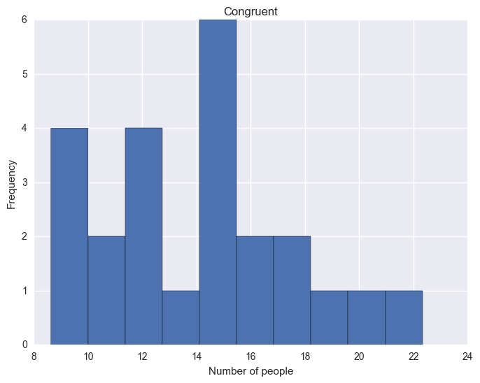

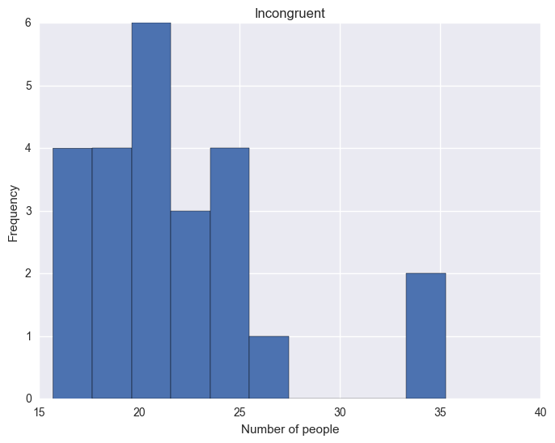

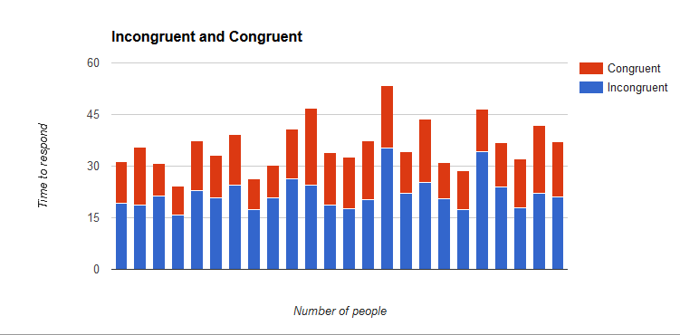

```python
# import all necessary packages and functions.
import csv
import pandas as pd
from IPython.display import display
from babs_visualizations import usage_plot

from IPython.display import Image
from IPython.core.display import HTML

sample_data = pd.read_csv('stroopdata.csv')

usage_plot(sample_data, 'Congruent')
usage_plot(sample_data, 'Incongruent')

Image("Histogram.png")
```

**Question 5**: Now, perform the statistical test and report your results. What is your confidence level and your critical statistic value? Do you reject the null hypothesis or fail to reject it? Come to a conclusion in terms of the experiment task. Did the results match up with your expectations?

**Answer**:

1. Mean difference d = Xi - Xc = 22.016 - 14.051 = 7.965
2. Standard deviation of the differences Sd = sqrt [ (Σ(di - d)^2 / (n - 1) ] = 4.865
3. Standard error of the mean difference SE(d) = Sd / sqrt (n) = 4.865 / sqrt(24) = 0.993
4. t-statistic t = d / SE(d) = 7.965 / 0.993 = 8.021
5. Degree of freedom DF = n - 1 = 23
6. alpha-level = 0.05
7. t-critical = 1.714
8. probability p <.0001

The one-tailed p value is less than 0.0001. By conventional criteria, this difference is considered to be extremely statistically significant (< 0.05). Therefore we reject H0. It means that it takes more time to say color of the ink from incongruent set than from congruent.

And yes, the results matched up with my expectations.

## Used Resources

1. http://www.investopedia.com/terms/d/descriptive_statistics.asp
2. http://stattrek.com/hypothesis-test/paired-means.aspx?Tutorial=AP
3. http://oak.ucc.nau.edu/rh232/courses/EPS525/Handouts/Understanding%20the%20Dependent%20t%20Test.pdf
4. http://graphpad.com/quickcalcs
5. http://vassarstats.net/